# Final Paper

STOR 320.01 Group 19: Sunny Sun

November 17, 2020

# INTRODUCTION

The worldwide coronavirus disease (COVID-19) is a viral infection that generates severe respiratory syndrome and has resulted in over 1 million deaths worldwide since its outbreak. In the U.S., from late January until the present, we have seen both the total number of confirmed cases and the total number of deaths undergo exponential growth. As of early October 2020, the total number of confirmed cases in the U.S. reached 7.5 million, with the total number of recovered cases hitting 4.3 million. In comparison to China, where the spread of the virus has slowed and entered a steady state, the United States continues to experience exponential growth in both COVID cases and deaths. Statistically, we are interested in exploring potential causal factors contributing to and exacerbating COVID-19 spread and mortality. In particular, rather than directly taking the mortality rate as our dependent variable, the `case fatality ratio` gives a more precise measure of the disease’s lethality by reporting the number of deaths divided by the number of confirmed cases in an area. Because COVID infection rates and case fatality ratio vary substantially across the United States, we performed our analysis on individual counties, allowing us to compare case fatality ratio to county-level metrics. This analysis will provide valuable information to policy makers interested in learning which factors are predictive of high rates of COVID infection and mortality.

Besides exploring the factors behind the COVID-19 case fatality ratio, we were interested in understanding the disease’s economic impact across the United States. Specifically, we wanted to evaluate factors that might determine which states are more likely to suffer a severe detrimental impact as a result of COVID-19. Between Q1 2020 and Q2 2020 some industries have experienced a more dramatic drop in percent contribution to GDP than others. The Energy and Metal sectors, for example, have lost 15% in their overall contribution to GDP. One might therefore expect states that are highly dependent on these sectors, such as Wyoming and Texas, to suffer a severe economic impact due to COVID-19. Similar to changes in GDP, most economic metrics are directly reflected by regions’ core industries competence and performance. We are therefore interested in evaluating COVID-19’s impacts on different industries by different regions in the U.S. Statistically, it would explicitly illustrate which industry in a given region has been most severely impacted by the virus. From a policy standpoint, these results could help the local government execute favorable policies to prop up industries harmed disproportionately by the virus. Additionally, these results could help guide the Federal Reserve in issuing a stimulus package for the U.S. economy, ameliorating the catastrophic COVID-19 impacts on the countries’ economic development in the post-COVID stage.

Our analysis addresses two primary questions – *first*, **“What are some of the deterministic factors that are responsible for COVID-19’s case fatality ratio?”**; *second*, **“What factors are responsible for state-level differences in the economic impact of COVID-19?”** These questions are interesting for investigation because the insights from each could inform a county, a state, a region, or even a country about specific factors that may influence the spread of COVID-19, as well as the industries most in need of economic help to avoid collapse.

# DATA

We downloaded our major dataset, current COVID-19 datasets, from the John Hopkins University Center for Systems Science and Engineering (JHU CSSE) data repository using the covid19.analytics R package. Datasets are continuously updated to provide the latest information on COVID-19. All of the datasets that we used are censuses, rather than samples from a larger population. Each observation (row) represents results for a specific geographical region (e.g., U.S. county). The time-series(ts) datasets we used in our analysis incorporate the number of confirmed cases, deaths and recovered cases, allowing us to relate state-level and county-level COVID statistic with other state-level and county-level variables. As for the specific dataset we used, the *ts-confirmed* dataset is a timeseries table of confirmed COVID-19 cases across the world, separated by country and region. This dataset includes 269 observations as of 2020-11-17. Fields include `Province.State` which lists the province or state, `Country.Region` which lists the country or region, Latitude and Longitude, plus a set of date columns. Similarly, the dataset *ts-deaths* is a ts table of confirmed COVID 19 deaths across the world, which includes 269 observations as of 2020-11-17 with the same coverage of variables. A *ts-recovered* is another table of confirmed COVID 19 recovered cases across the world, separated by country and region. This dataset includes 256 observations as of 2020-11-17 with the same variables as the other ts datasets.

Our first question specifically investigates the `case fatality ratio`. We used the *aggregated* dataset, a non-ts table displaying confirmed cases, deaths, recovered cases, active cases, incident rate, and `case fatality ratio`. For our analysis, we only used the fields `Province_State`, which reports the U.S. state, `Admin2` which reports the U.S. county, and `case fatality ratio` which reports the case fatality ratio, the ratio of fatal cases to confirmed cases. The following table displays the most important variables that we used in our analysis.

| Admin2 | Province_State | Confirmed | Deaths | Recovered | Case_Fatality_Ratio |
| --- | --- | --- | --- | --- | --- |
| Calhoun | Georgia | 306 | 10 | 0 | 3.26797385620915 |
| Camden | Georgia | 1644 | 20 | 0 | 1.21654501216545 |
| Candler | Georgia | 602 | 29 | 0 | 4.81727574750831 |
| Carroll | Georgia | 4921 | 90 | 0 | 1.82889656573867 |
| Catoosa | Georgia | 1757 | 26 | 0 | 1.47979510529311 |
| Charlton | Georgia | 757 | 16 | 0 | 2.11360634081902 |
| Chatham | Georgia | 10196 | 202 | 0 | 1.98116908591605 |
| Chattahoochee | Georgia | 1937 | 2 | 0 | 0.103252452245741 |
| Chattooga | Georgia | 1158 | 32 | 0 | 2.76338514680484 |
| Cherokee | Georgia | 9144 | 113 | 0 | 1.23578302712161 |

[output cut: 1 more lines]

To further explore the explanatory variables that could explain the dependent variable - `case fatality ratio`, we consulted the *county complete* dataset downloaded from the University of Oxford COVID-19 Research Center. The dataset aggregates potential causal factors into various categories, including various age groups (e.g. `age_under_5_2017`), educational attainment (e.g. `bachelors_2017`), racial groups (e.g. `white_2017`), etc. In our EDA, we conducted multiple simple linear regression models by using some of variables in each of the representative category to try to explain its effect on the `case_fatality ratio`. In our exploration on the first final question- the combination of deterministic factors that could result in high predictive power, we applied the dataset twice - first, we used all potential causal factors to conduct selection processes of final variables of interest; second, using the same suite of independent variables we applied an alternative regression technique, random forest. In particular, the *county complete* dataset has 3142 observations that collects data results on a county’s level, which can be considered as a comprehensive census for analyzing variables of interest among various aspects/fields. However, the dataset that Oxford Research Center used dated back to 2017, so we were still concerned with data inconsistencies due to this temporal mismatch. Moreover, in assessing factors that may influence `case fatality ratio`, we obtained additional county-level data from outside sources. Specifically, we imported the *hospital beds USA* dataset that obtained from the COVID Tracking Project, which is an authoritative organization collecting datasets from the CDC on a state level and health organizations on a county level. The *hospital beds USA* dataset is comprised of 5713 observations with each observation representing a county within a given state. In particular, to investigate the relationship between hospital capacity related metrics and `case fatality ratio` in our first question, we were interested in `hospital beds` and the `pop` that recorded at the beginning of 2020 from this dataset. As for `hospital beds`, it also indicates the type of each bed - “ICU”/“Acute”/“Psychatric”/“Other”, which adds more accuracy in the data collection process.

Our second question specifically investigates state-level differences in the economic impact of COVID-19. We included three datasets that were collected by the U.S. Bureau of Economic Analysis: first, the dataset *State Change GDP* helps to explicitly display the extent of how COVID-19 impacts each state since its outbreak in the U.S., measured by the change in % of GDP since March, 2020; second, the dataset *GDP by Region and Industry* assesses impacts on the regions’s level but with the illustration of industries’ performance under the pandemic era; lastly, the dataset *Percent_GDP_by_State* shows a state-level composition of industries that are responsible for states’ GDP on a much more granular level. The *State Change GDP* dataset is a table displaying state-level GDP between Q1 2019 and Q2 2020, from which we calculated percent change in GDP between `Q2 2019` and `Q2 2020`. This dataset has 51 observations pertaining to the 50 U.S. states plus Washington D.C. This dataset represents a full census of state level GDP data for the United States. Below is a heat map displaying the extent of COVID’s influences on each state in terms of GDP changes.

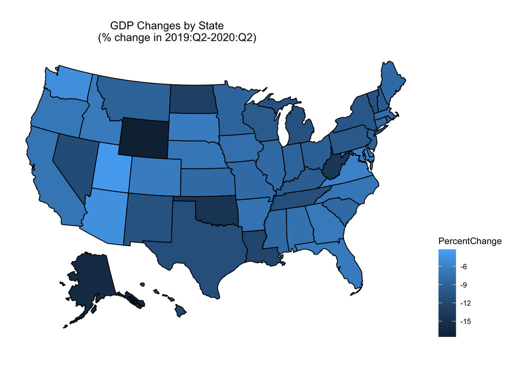

To further examine changes in contributions to GDP across industries and U.S regions, we incorporated the dataset *GDP by Region and Industry* into our analysis. This dataset shows `Contributions to Percent Change in GDP` by U.S. Region from Q1 2020 to Q2 2020, and represents summary values for various industries across the United States and thus is not a sample drawn from a larger population. This dataset contains 8 observations, pertaining to geographic regions within the United States. Industries are reported as our variables of interest, including `Agriculture`, `Manufacturing`, and `Retail`. Below is a descriptive figure that displays the contributions to GDP changes by industries and by regions.

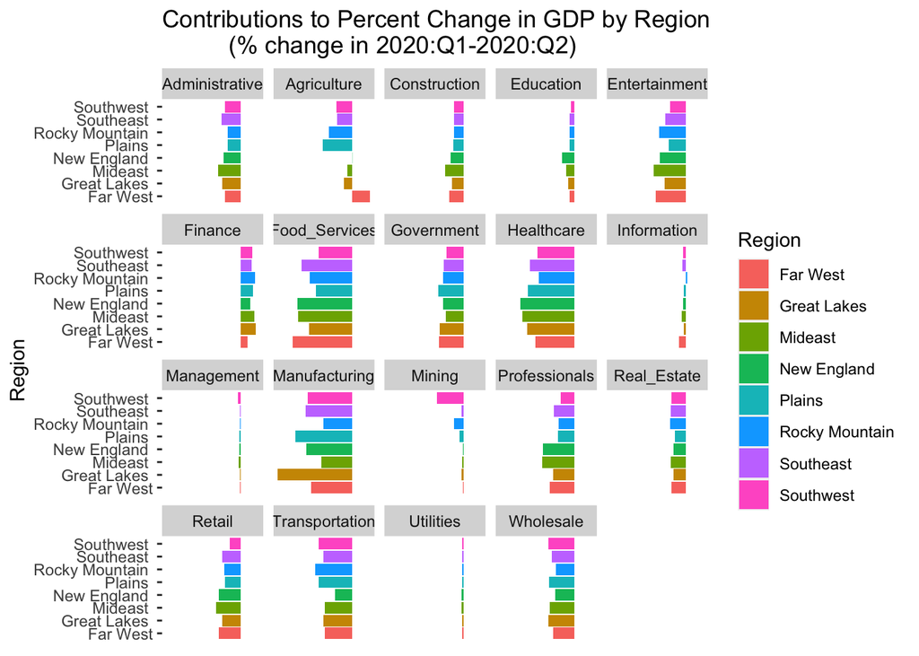

Our last dataset *Percent_GDP_by_State* decomposes state level GDP into different industries. It is an informative table that is comprised of 20 observations with each observation representing different industries. All columns are our variables of interest since we need to address the second final question on a state level.

# Question 1: What are some of the deterministic factors that are responsible for COVID-19’s case fatality ratio?

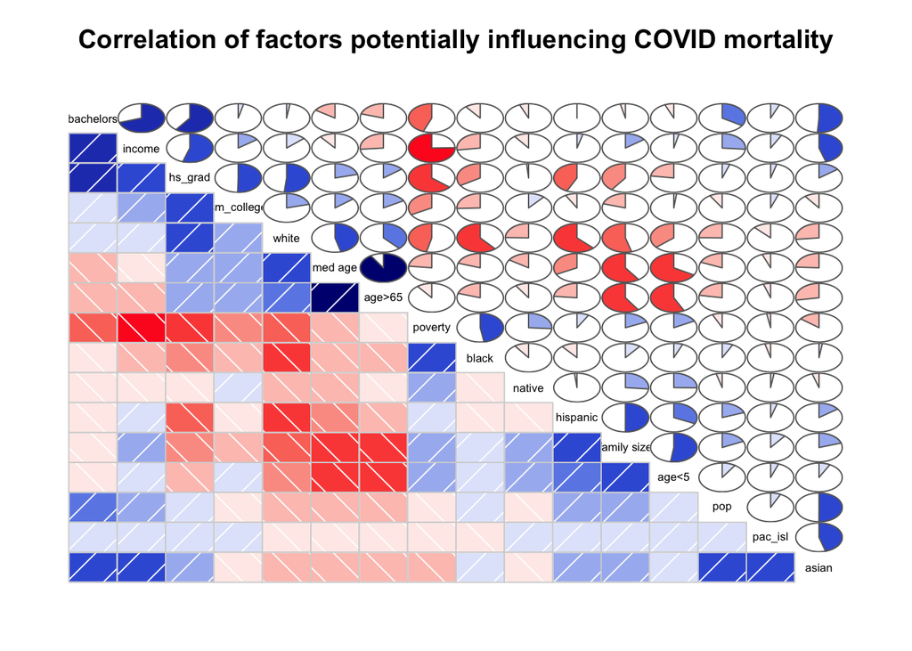

In order to assess the fit of our model we used a 10 fold cross validation on the final model we created previously, using 80% of our data as our training data and 20% as our testing data. After each fold, we calculated mean average error (MAE) on the testing dataset. The mean MAE value for the 10-fold cross validation was 0.01239817. Additionally, after each fold we calculated the residuals for the testing data and exported these as a numeric vector. We created a frequency histogram and density plot to make sure the residuals were normally distributed with a mean of zero.

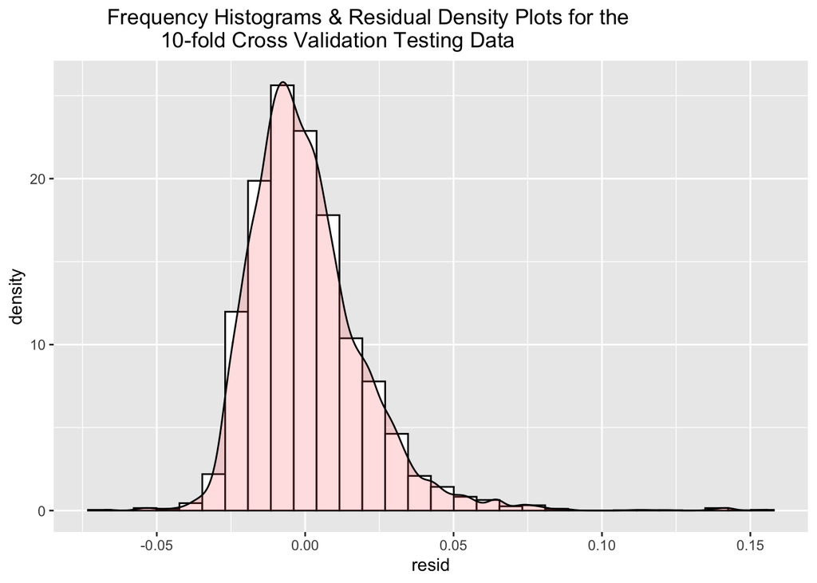

As with the linear model, we used a 10-fold cross validation, where 80% of our data was used to train the model and 20% was used to test the model. After each fold, we calculated mean average error (MAE) on the testing dataset. In the cross-validated random forest model, the mean MAE value for the 10-fold cross validation was 0.01195932. Additionally, after each fold we calculated the residuals for the testing data and exported these as a numeric vector. We created a frequency histogram and density plot to make sure the residuals were normally distributed with a mean of zero. As we incorporated `hs_grads_2017` in our final model, we then created a partial dependence plot for `hs_grads_2017` to assess the nature of the relationship between this variable and case fatality ratio. Partial dependence plots work by fixing all variables other than the variable of interest at their mean value. Next, the algorithm iterates through all possible values of the variable of interest (in this case `hs_grads_2017`) and records the effect on predicted outcome. The resultant plot can be used to determine whether the variable of interest has a positive or negative effect on the response variable.

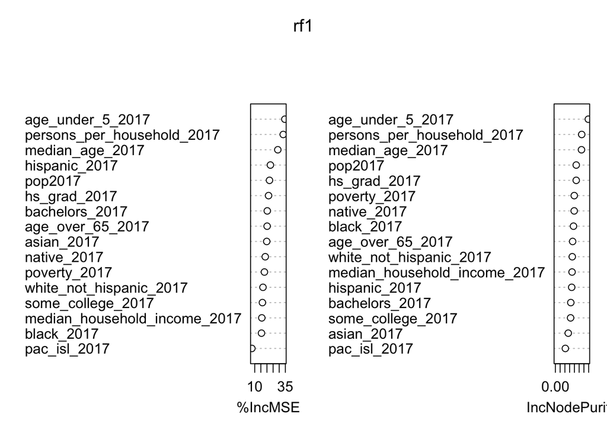

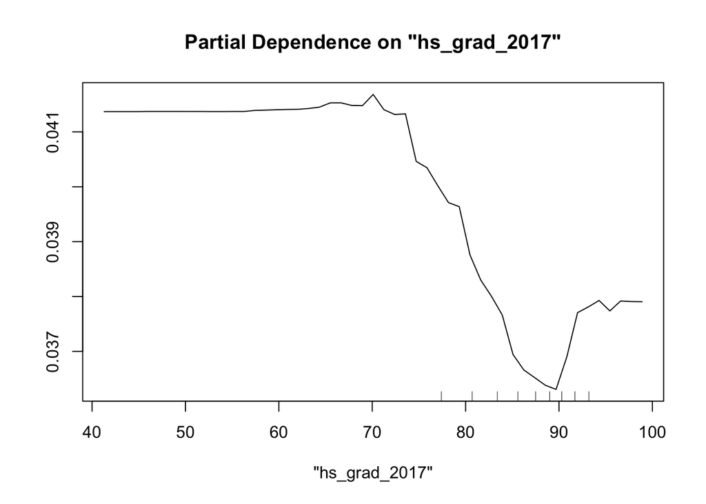

After comparing MAE and residual plots between the random forests model and the linear model we again concluded that the predictive power of these techniques is remarkably similar for this dataset. We concluded that the 5 variables we selected as being determinants of case fatality ratio produce similar results regardless of the regression algorithm used. To visualize the relationships between our independent variables and case fatality ratio, we calculated 95% confidence intervals for the coefficients for all independent variables and plotted these using a dot and whisker plot. Typically, 95% confidence intervals that are entirely positive indicate a variable that has a positive effect on the dependent variable whereas those that are entirely negative indicate a negative effect on the dependent variable. Those 95% confidence intervals that overlap zero typically cannot be said to have either a positive or negative effect on the dependent variable.

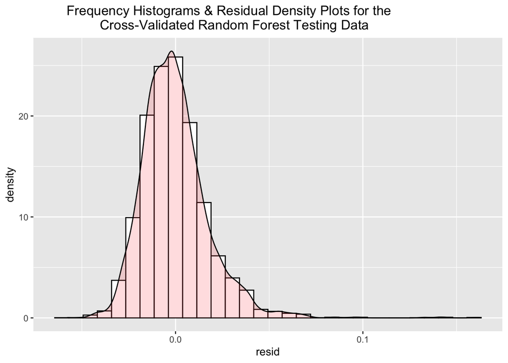

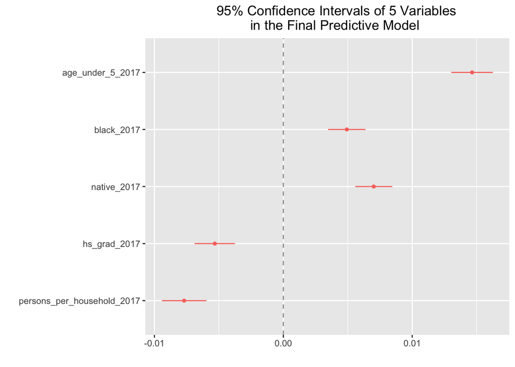

# Question2: What factors are responsible for state-level differences in the economic impact of COVID-19?

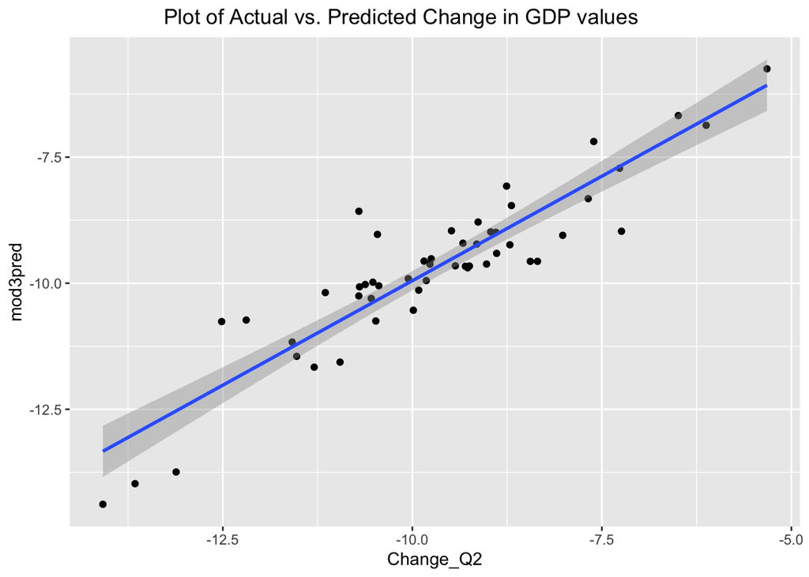

# CONCLUSION

The results of the first follow-up question indicate that explanatory variables including “the percentage of people aged under 5”, “% of population comprised of black racial group”, “% of population comprised of native racial group”, “% of population who earned high-school degree”, and “the number of persons per household” have the highest predictive power for the COVID-19 case fatality ratio. From the 95% confidence intervals, we found younger population and both black and native racial groups to have a positive correlation with the case fatality ratio. In contrast, higher educational attainment, defined as the percentage of the population with a high school diploma, was negative correlated with case fatality ratio. The only counter-intuitive result we concluded here is the negative correlation between the percentage of persons per household and case fatality ratio. These results are invaluable to both the local and national disease control agencies. For example, CDC could use the results from our first question in delivering more effective guidelines to control the nation’s case fatality ratio by first filtering out states or even counties with the highest percentage of black and native population, and then enforce more effective quarantine or COVID-testing policies on those states/counties. On the other hand, in regions possessing high educational attainment, the corresponding states should encourage more highly educated people to distribute the scientific disease control methods in their households. As for the last factor we indicated in the final model, we should be mindful if the household size is relatively small, which may indicate less likelihood for small households to conduct the necessary COVID-testing as their impacts to county case fatality ratio is relatively minimal.

Future researchers may wish to follow up on our analysis by digging deeper into the factors that make states and counties more or less susceptible to COVID-19 outbreaks. We were unable to obtain high-quality information on the prevalence and efficacy of measures intended to combat the spread of COVID-19, yet it is well known that measures such as mask mandates and lockdowns vary widely by jurisdiction. A detailed time-series dataset with start and end dates for each COVID mitigation mandate would provide valuable information on the types of measures most likely to stop the spread of this virus.

Moving forward, more research is needed in order to uncover the relationship between county level predictors and case fatality ratio. Certain demographic factors, such as the percentage of black or Native American people in a county, are highly correlated with case fatality ratio. However, it is beyond the scope of our analysis to ask why these factors contribute to case fatality ratio. Future researchers could attempt to understand why these populations suffer a disproportionate mortality rate with COVID-19.